# BABI DataMining Group 10

```r
summary(HR_Data)
```

```
##       Age         Attrition         BusinessTravel       DailyRate
##  Min.   :18.00   Length:2940        Length:2940        Min.   : 102.0
##  1st Qu.:30.00   Class :character   Class :character   1st Qu.: 465.0
##  Median :36.00   Mode  :character   Mode  :character   Median : 802.0
##  Mean   :36.92                                         Mean   : 802.5
##  3rd Qu.:43.00                                         3rd Qu.:1157.0
##  Max.   :60.00                                         Max.   :1499.0
##   Department        DistanceFromHome   Education     EducationField
##  Length:2940        Min.   : 1.000   Min.   :1.000   Length:2940
##  Class :character   1st Qu.: 2.000   1st Qu.:2.000   Class :character
##  Mode  :character   Median : 7.000   Median :3.000   Mode  :character
##                     Mean   : 9.193   Mean   :2.913
##                     3rd Qu.:14.000   3rd Qu.:4.000
##                     Max.   :29.000   Max.   :5.000
##  EmployeeCount EmployeeNumber   EnvironmentSatisfaction    Gender
##  Min.   :1     Min.   :   1.0   Min.   :1.000           Length:2940
##  1st Qu.:1     1st Qu.: 735.8   1st Qu.:2.000           Class :character
##  Median :1     Median :1470.5   Median :3.000           Mode  :character
##  Mean   :1     Mean   :1470.5   Mean   :2.722
##  3rd Qu.:1     3rd Qu.:2205.2   3rd Qu.:4.000
##  Max.   :1     Max.   :2940.0   Max.   :4.000
##    HourlyRate     JobInvolvement    JobLevel       JobRole
##  Min.   : 30.00   Min.   :1.00   Min.   :1.000   Length:2940
##  1st Qu.: 48.00   1st Qu.:2.00   1st Qu.:1.000   Class :character
##  Median : 66.00   Median :3.00   Median :2.000   Mode  :character
##  Mean   : 65.89   Mean   :2.73   Mean   :2.064
##  3rd Qu.: 84.00   3rd Qu.:3.00   3rd Qu.:3.000
##  Max.   :100.00   Max.   :4.00   Max.   :5.000
##  JobSatisfaction MaritalStatus      MonthlyIncome    MonthlyRate
##  Min.   :1.000   Length:2940        Min.   : 1009   Min.   : 2094
##  1st Qu.:2.000   Class :character   1st Qu.: 2911   1st Qu.: 8045
##  Median :3.000   Mode  :character   Median : 4919   Median :14236
##  Mean   :2.729                      Mean   : 6503   Mean   :14313
##  3rd Qu.:4.000                      3rd Qu.: 8380   3rd Qu.:20462
##  Max.   :4.000                      Max.   :19999   Max.   :26999
##  NumCompaniesWorked    Over18            OverTime
##  Min.   :0.000      Length:2940        Length:2940
##  1st Qu.:1.000      Class :character   Class :character
##  Median :2.000      Mode  :character   Mode  :character
##  Mean   :2.693
```

[output cut: 15 more lines]

```
##  Max.   :80    Max.   :3.0000   Max.   :40.00     Max.   :6.000
##  WorkLifeBalance YearsAtCompany   YearsInCurrentRole
##  Min.   :1.000   Min.   : 0.000   Min.   : 0.000
##  1st Qu.:2.000   1st Qu.: 3.000   1st Qu.: 2.000
##  Median :3.000   Median : 5.000   Median : 3.000
##  Mean   :2.761   Mean   : 7.008   Mean   : 4.229
##  3rd Qu.:3.000   3rd Qu.: 9.000   3rd Qu.: 7.000
##  Max.   :4.000   Max.   :40.000   Max.   :18.000
##  YearsSinceLastPromotion YearsWithCurrManager
##  Min.   : 0.000          Min.   : 0.000
##  1st Qu.: 0.000          1st Qu.: 2.000
##  Median : 1.000          Median : 3.000
##  Mean   : 2.188          Mean   : 4.123
##  3rd Qu.: 3.000          3rd Qu.: 7.000
##  Max.   :15.000          Max.   :17.000
```

```r
 HR_Data$Attrition <- as.factor(HR_Data$Attrition)
 HR_Data$BusinessTravel   <- as.factor(HR_Data$BusinessTravel)
 HR_Data$Department  <- as.factor(HR_Data$Department)
 HR_Data$EducationField  <- as.factor(HR_Data$EducationField)
 HR_Data$Gender  <- as.factor(HR_Data$Gender)
 HR_Data$JobRole <- as.factor(HR_Data$JobRole)
 HR_Data$MaritalStatus <- as.factor(HR_Data$MaritalStatus)
 HR_Data$Over18 <- as.factor(HR_Data$Over18)
 HR_Data$OverTime <- as.factor(HR_Data$OverTime)

 str(HR_Data)
```

```
## Classes 'spec_tbl_df', 'tbl_df', 'tbl' and 'data.frame': 2940 obs. of  35 variables:
##  $ Age                     : num  41 49 37 33 27 32 59 30 38 36 ...
##  $ Attrition               : Factor w/ 2 levels "No","Yes": 2 1 2 1 1 1 1 1 1 1 ...
##  $ BusinessTravel          : Factor w/ 3 levels "Non-Travel","Travel_Frequently",..: 3 2 3 2 3 2 3 3 2 3 ...
##  $ DailyRate               : num  1102 279 1373 1392 591 ...
##  $ Department              : Factor w/ 3 levels "Human Resources",..: 3 2 2 2 2 2 2 2 2 2 ...
##  $ DistanceFromHome        : num  1 8 2 3 2 2 3 24 23 27 ...
##  $ Education               : num  2 1 2 4 1 2 3 1 3 3 ...
##  $ EducationField          : Factor w/ 6 levels "Human Resources",..: 2 2 5 2 4 2 4 2 2 4 ...
##  $ EmployeeCount           : num  1 1 1 1 1 1 1 1 1 1 ...
##  $ EmployeeNumber          : num  1 2 3 4 5 6 7 8 9 10 ...
##  $ EnvironmentSatisfaction : num  2 3 4 4 1 4 3 4 4 3 ...
##  $ Gender                  : Factor w/ 2 levels "Female","Male": 1 2 2 1 2 2 1 2 2 2 ...
##  $ HourlyRate              : num  94 61 92 56 40 79 81 67 44 94 ...
##  $ JobInvolvement          : num  3 2 2 3 3 3 4 3 2 3 ...
##  $ JobLevel                : num  2 2 1 1 1 1 1 1 3 2 ...
##  $ JobRole                 : Factor w/ 9 levels "Healthcare Representative",..: 8 7 3 7 3 3 3 3 5 1 ...
##  $ JobSatisfaction         : num  4 2 3 3 2 4 1 3 3 3 ...
##  $ MaritalStatus           : Factor w/ 3 levels "Divorced","Married",..: 3 2 3 2 2 3 2 1 3 2 ...
##  $ MonthlyIncome           : num  5993 5130 2090 2909 3468 ...
##  $ MonthlyRate             : num  19479 24907 2396 23159 16632 ...
##  $ NumCompaniesWorked      : num  8 1 6 1 9 0 4 1 0 6 ...
##  $ Over18                  : Factor w/ 1 level "Y": 1 1 1 1 1 1 1 1 1 1 ...
##  $ OverTime                : Factor w/ 2 levels "No","Yes": 2 1 2 2 1 1 2 1 1 1 ...
##  $ PercentSalaryHike       : num  11 23 15 11 12 13 20 22 21 13 ...
##  $ PerformanceRating       : num  3 4 3 3 3 3 4 4 4 3 ...
##  $ RelationshipSatisfaction: num  1 4 2 3 4 3 1 2 2 2 ...
##  $ StandardHours           : num  80 80 80 80 80 80 80 80 80 80 ...
##  $ StockOptionLevel        : num  0 1 0 0 1 0 3 1 0 2 ...
##  $ TotalWorkingYears       : num  8 10 7 8 6 8 12 1 10 17 ...
##  $ TrainingTimesLastYear   : num  0 3 3 3 3 2 3 2 2 3 ...
##  $ WorkLifeBalance         : num  1 3 3 3 3 2 2 3 3 2 ...
##  $ YearsAtCompany          : num  6 10 0 8 2 7 1 1 9 7 ...
##  $ YearsInCurrentRole      : num  4 7 0 7 2 7 0 0 7 7 ...
##  $ YearsSinceLastPromotion : num  0 1 0 3 2 3 0 0 1 7 ...
##  $ YearsWithCurrManager    : num  5 7 0 0 2 6 0 0 8 7 ...
##  - attr(*, "spec")=
##   .. cols(
##   ..   Age = col_double(),
##   ..   Attrition = col_character(),
```

[output cut: 19 more lines]

```
##   ..   Over18 = col_character(),
##   ..   OverTime = col_character(),
##   ..   PercentSalaryHike = col_double(),
##   ..   PerformanceRating = col_double(),
##   ..   RelationshipSatisfaction = col_double(),
##   ..   StandardHours = col_double(),
##   ..   StockOptionLevel = col_double(),
##   ..   TotalWorkingYears = col_double(),
##   ..   TrainingTimesLastYear = col_double(),
##   ..   WorkLifeBalance = col_double(),
##   ..   YearsAtCompany = col_double(),
##   ..   YearsInCurrentRole = col_double(),
##   ..   YearsSinceLastPromotion = col_double(),
##   ..   YearsWithCurrManager = col_double()
##   .. )
```

```r
library(lattice)
library(ggplot2)
library(corrplot)
library(ggpubr)
library(ggplot2)
library(corrplot)
```

```r
names(HR_Data)
```

```
##  [1] "Age"                      "Attrition"
##  [3] "BusinessTravel"           "DailyRate"
##  [5] "Department"               "DistanceFromHome"
##  [7] "Education"                "EducationField"
##  [9] "EmployeeCount"            "EmployeeNumber"
## [11] "EnvironmentSatisfaction"  "Gender"
## [13] "HourlyRate"               "JobInvolvement"
## [15] "JobLevel"                 "JobRole"
## [17] "JobSatisfaction"          "MaritalStatus"
## [19] "MonthlyIncome"            "MonthlyRate"
## [21] "NumCompaniesWorked"       "Over18"
## [23] "OverTime"                 "PercentSalaryHike"
## [25] "PerformanceRating"        "RelationshipSatisfaction"
## [27] "StandardHours"            "StockOptionLevel"
## [29] "TotalWorkingYears"        "TrainingTimesLastYear"
## [31] "WorkLifeBalance"          "YearsAtCompany"
## [33] "YearsInCurrentRole"       "YearsSinceLastPromotion"
## [35] "YearsWithCurrManager"
```

```r
HR_Data_Corr <- subset(HR_Data, select = -c(Attrition , BusinessTravel  , Department , EducationField , Gender , JobRole , MaritalStatus , Over18 , OverTime  ))

str(HR_Data_Corr)
```

```
## Classes 'tbl_df', 'tbl' and 'data.frame':    2940 obs. of  26 variables:
##  $ Age                     : num  41 49 37 33 27 32 59 30 38 36 ...
##  $ DailyRate               : num  1102 279 1373 1392 591 ...
##  $ DistanceFromHome        : num  1 8 2 3 2 2 3 24 23 27 ...
##  $ Education               : num  2 1 2 4 1 2 3 1 3 3 ...
##  $ EmployeeCount           : num  1 1 1 1 1 1 1 1 1 1 ...
##  $ EmployeeNumber          : num  1 2 3 4 5 6 7 8 9 10 ...
##  $ EnvironmentSatisfaction : num  2 3 4 4 1 4 3 4 4 3 ...
##  $ HourlyRate              : num  94 61 92 56 40 79 81 67 44 94 ...
##  $ JobInvolvement          : num  3 2 2 3 3 3 4 3 2 3 ...
##  $ JobLevel                : num  2 2 1 1 1 1 1 1 3 2 ...
##  $ JobSatisfaction         : num  4 2 3 3 2 4 1 3 3 3 ...
##  $ MonthlyIncome           : num  5993 5130 2090 2909 3468 ...
##  $ MonthlyRate             : num  19479 24907 2396 23159 16632 ...
##  $ NumCompaniesWorked      : num  8 1 6 1 9 0 4 1 0 6 ...
##  $ PercentSalaryHike       : num  11 23 15 11 12 13 20 22 21 13 ...
##  $ PerformanceRating       : num  3 4 3 3 3 3 4 4 4 3 ...
##  $ RelationshipSatisfaction: num  1 4 2 3 4 3 1 2 2 2 ...
##  $ StandardHours           : num  80 80 80 80 80 80 80 80 80 80 ...
##  $ StockOptionLevel        : num  0 1 0 0 1 0 3 1 0 2 ...
##  $ TotalWorkingYears       : num  8 10 7 8 6 8 12 1 10 17 ...
##  $ TrainingTimesLastYear   : num  0 3 3 3 3 2 3 2 2 3 ...
##  $ WorkLifeBalance         : num  1 3 3 3 3 2 2 3 3 2 ...
##  $ YearsAtCompany          : num  6 10 0 8 2 7 1 1 9 7 ...
##  $ YearsInCurrentRole      : num  4 7 0 7 2 7 0 0 7 7 ...
##  $ YearsSinceLastPromotion : num  0 1 0 3 2 3 0 0 1 7 ...
##  $ YearsWithCurrManager    : num  5 7 0 0 2 6 0 0 8 7 ...
```

```r
cor(HR_Data_Corr)
```

```
##                                   Age     DailyRate DistanceFromHome
## Age                       1.000000000  0.0106609426     -0.001686120
## DailyRate                 0.010660943  1.0000000000     -0.004985337
## DistanceFromHome         -0.001686120 -0.0049853374      1.000000000
## Education                 0.208033731 -0.0168064332      0.021041826
## EmployeeCount                      NA            NA               NA
## EmployeeNumber           -0.005174672 -0.0257418149      0.016464171
## EnvironmentSatisfaction   0.010146428  0.0183548543     -0.016075327
## HourlyRate                0.024286543  0.0233814215      0.031130586
## JobInvolvement            0.029819959  0.0461348740      0.008783280
## JobLevel                  0.509604228  0.0029663349      0.005302731
## JobSatisfaction          -0.004891877  0.0305710078     -0.003668839
## MonthlyIncome             0.497854567  0.0077070589     -0.017014445
## MonthlyRate               0.028051167 -0.0321816015      0.027472864
## NumCompaniesWorked        0.299634758  0.0381534343     -0.029250804
## PercentSalaryHike         0.003633585  0.0227036775      0.040235377
## PerformanceRating         0.001903896  0.0004732963      0.027109618
## RelationshipSatisfaction  0.053534720  0.0078460310      0.006557475
## StandardHours                      NA            NA               NA
## StockOptionLevel          0.037509712  0.0421427964      0.044871999
## TotalWorkingYears         0.680380536  0.0145147387      0.004628426
## TrainingTimesLastYear    -0.019620819  0.0024525427     -0.036942234
## WorkLifeBalance          -0.021490028 -0.0378480510     -0.026556004
## YearsAtCompany            0.311308770 -0.0340547676      0.009507720
## YearsInCurrentRole        0.212901056  0.0099320150      0.018844999
## YearsSinceLastPromotion   0.216513368 -0.0332289848      0.010028836
## YearsWithCurrManager      0.202088602 -0.0263631782      0.014406048
##                             Education EmployeeCount EmployeeNumber
## Age                       0.208033731            NA  -0.0051746719
## DailyRate                -0.016806433            NA  -0.0257418149
## DistanceFromHome          0.021041826            NA   0.0164641708
## Education                 1.000000000            NA   0.0209502859
## EmployeeCount                      NA             1             NA
## EmployeeNumber            0.020950286            NA   1.0000000000
## EnvironmentSatisfaction  -0.027128313            NA   0.0087118301
## HourlyRate                0.016774829            NA   0.0173769037
## JobInvolvement            0.042437634            NA  -0.0035523572
## JobLevel                  0.101588886            NA  -0.0090203564
## JobSatisfaction          -0.011296117            NA  -0.0229704931
## MonthlyIncome             0.094960677            NA  -0.0071883547
```

[output cut: 242 more lines]

```
## MonthlyIncome                        0.344977638         0.3440788833
## MonthlyRate                          0.001566800        -0.0367459053
## NumCompaniesWorked                  -0.036813892        -0.1103191554
## PercentSalaryHike                   -0.022154313        -0.0119852485
## PerformanceRating                    0.017896066         0.0228271689
## RelationshipSatisfaction             0.033492502        -0.0008674968
## StandardHours                                 NA                   NA
## StockOptionLevel                     0.014352185         0.0246982266
## TotalWorkingYears                    0.404857759         0.4591883971
## TrainingTimesLastYear               -0.002066536        -0.0040955260
## WorkLifeBalance                      0.008941249         0.0027594402
## YearsAtCompany                       0.618408865         0.7692124251
## YearsInCurrentRole                   0.548056248         0.7143647616
## YearsSinceLastPromotion              1.000000000         0.5102236358
## YearsWithCurrManager                 0.510223636         1.0000000000
```

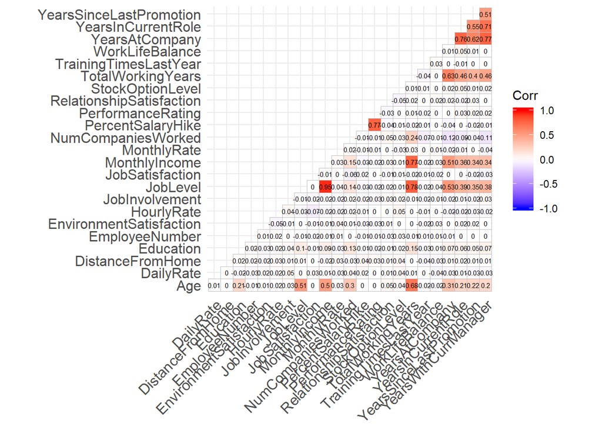

```r
#corrplot(HR_Data_Corr , method = "number" , type ="lower" ,  tl.cex = 1.2 , addgrid.col = "gray50" ,  mar=c(0,0,0,0) )


ggcorrplot::ggcorrplot(corr = cor(HR_Data_Corr), type= "lower" , lab = TRUE , lab_size = 2, insig = c("pch") )
```

*Stacked Bar chart for categorical variables with Target variable*

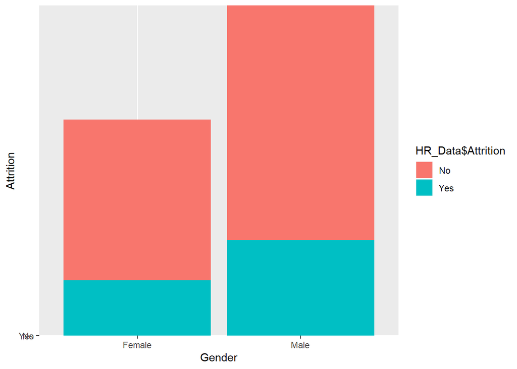

```r
Attr_Gender <- ggplot(HR_Data, aes(x = HR_Data$Gender , y = HR_Data$Attrition  , fill = HR_Data$Attrition))+
  geom_bar( position = "stack" , stat =  "identity" ) + xlab("Gender") + ylab("Attrition")

plot(Attr_Gender)
```

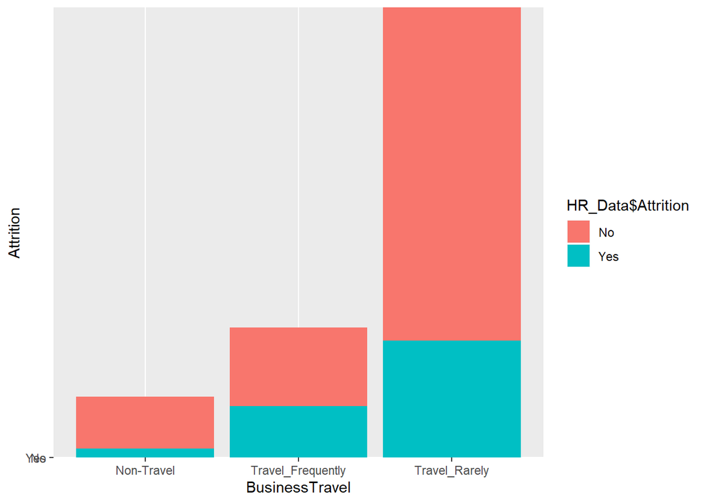

```r
Attr_BusinessTravel <- ggplot(HR_Data, aes(x = HR_Data$BusinessTravel , y = HR_Data$Attrition  , fill = HR_Data$Attrition))+
  geom_bar( position = "stack" , stat =  "identity" ) + xlab("BusinessTravel") + ylab("Attrition")

plot(Attr_BusinessTravel)
```

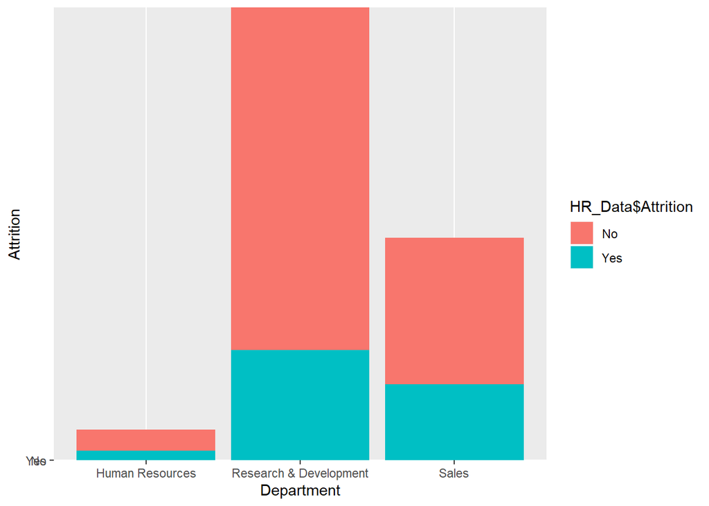

```r
Attr_Department <- ggplot(HR_Data, aes(x = HR_Data$Department , y = HR_Data$Attrition  , fill = HR_Data$Attrition))+
  geom_bar( position = "stack" , stat =  "identity" ) + xlab("Department") + ylab("Attrition")
plot(Attr_Department)
```

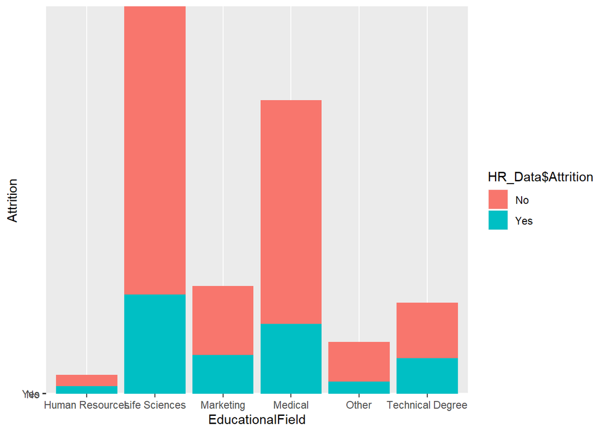

```r
Attr_EducationField <- ggplot(HR_Data, aes(x = HR_Data$EducationField , y = HR_Data$Attrition  , fill = HR_Data$Attrition))+
  geom_bar( position = "stack" , stat =  "identity" ) + xlab("EducationalField") + ylab("Attrition")

plot(Attr_EducationField)
```

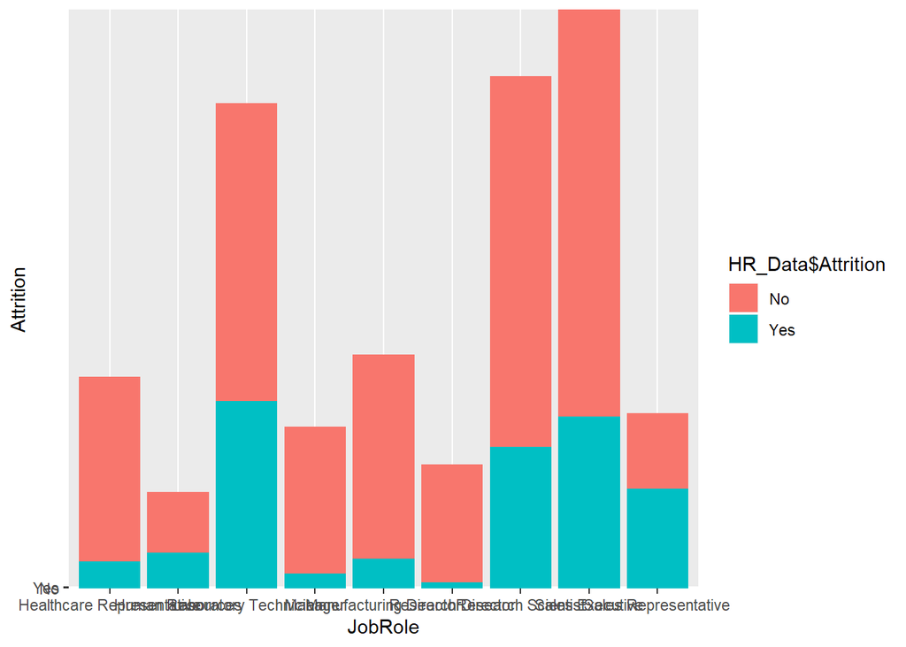

```r
Attr_JobRole <- ggplot(HR_Data, aes(x = HR_Data$JobRole , y = HR_Data$Attrition  , fill = HR_Data$Attrition))+
  geom_bar( position = "stack" , stat =  "identity" ) + xlab("JobRole") + ylab("Attrition")

plot(Attr_JobRole)
```

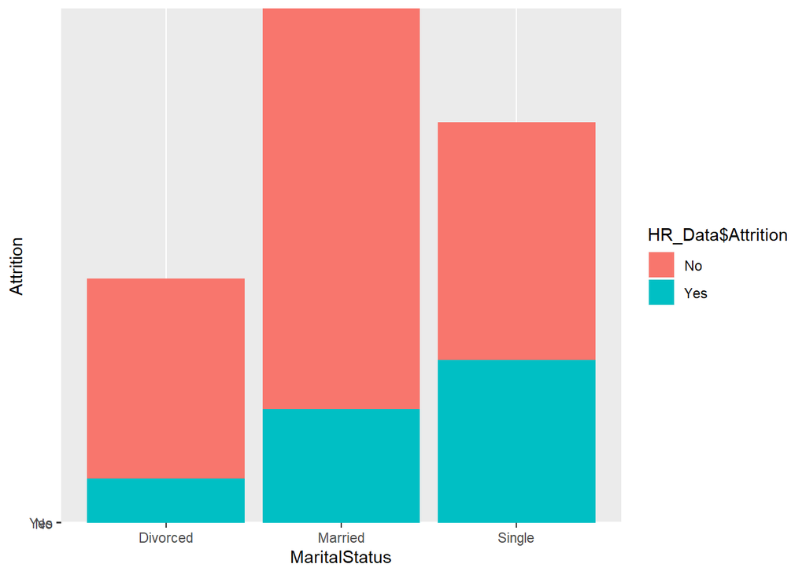

```r
Attr_MaritalStatus <- ggplot(HR_Data, aes(x = HR_Data$MaritalStatus , y = HR_Data$Attrition  , fill = HR_Data$Attrition))+
  geom_bar( position = "stack" , stat =  "identity" ) + xlab("MaritalStatus") + ylab("Attrition")

plot(Attr_MaritalStatus)
```

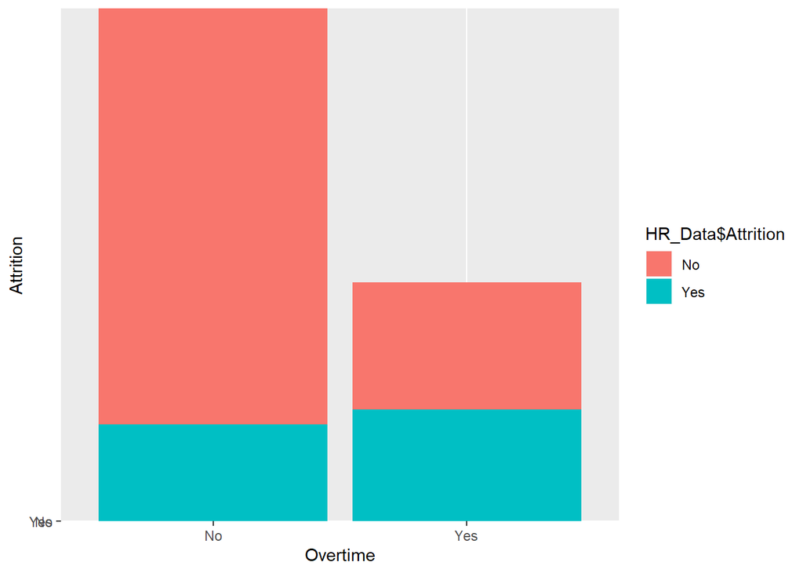

```r
Attr_OverTime <- ggplot(HR_Data, aes(x = HR_Data$OverTime , y = HR_Data$Attrition  , fill = HR_Data$Attrition))+
  geom_bar( position = "stack" , stat =  "identity" ) + xlab("Overtime") + ylab("Attrition")


plot(Attr_OverTime)
```

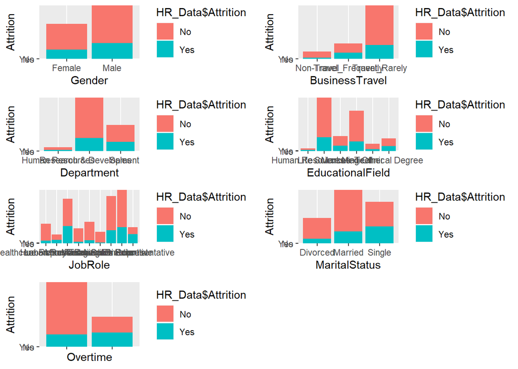

```r
ggarrange(Attr_Gender,  Attr_BusinessTravel , Attr_Department , Attr_EducationField, Attr_JobRole, Attr_MaritalStatus, Attr_OverTime  + rremove("x.text"),
          heights = c(4, 4 , 4 , 4), widths = c(15 ,15),
          ncol = 2, nrow = 4)
```

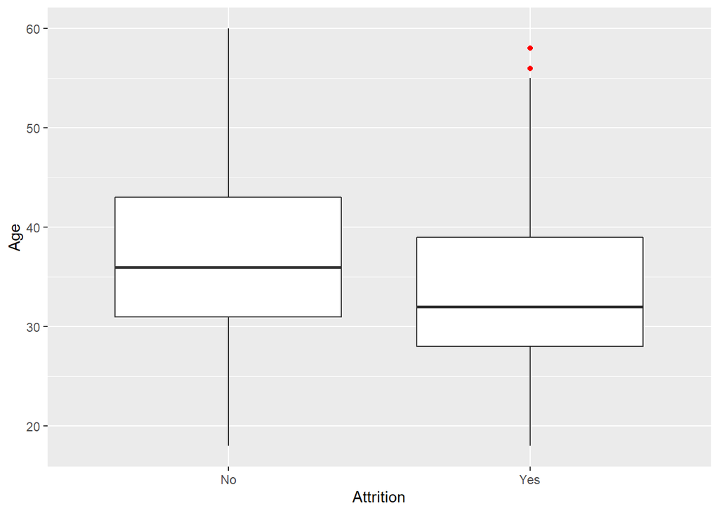

```r
# Age

Attr_Age <- ggplot(HR_Data, aes( x = HR_Data$Attrition  , y = HR_Data$Age))+
  geom_boxplot(stat ="boxplot" ,  outlier.colour = "red" ) + xlab("Attrition") + ylab("Age")

plot(Attr_Age)
```

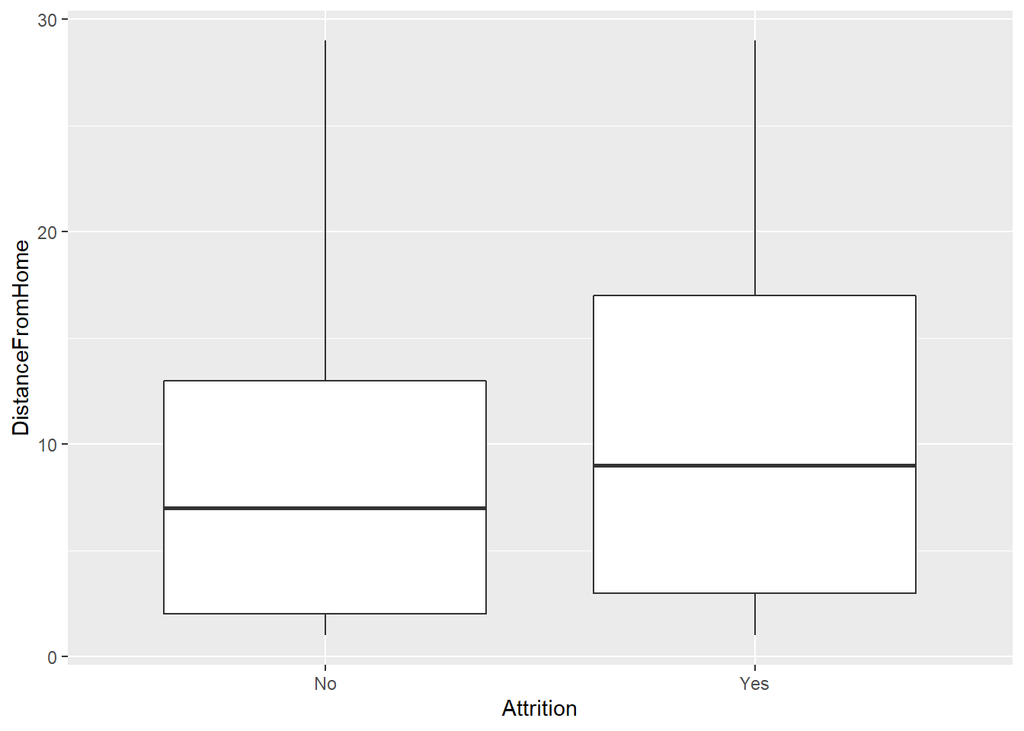

```r
# DistanceFromHome

Attr_DistanceFromHome <- ggplot(HR_Data, aes( x = HR_Data$Attrition  , y = HR_Data$DistanceFromHome))+
  geom_boxplot(stat ="boxplot" ,  outlier.colour = "red") + xlab("Attrition") + ylab("DistanceFromHome")

plot(Attr_DistanceFromHome)
```

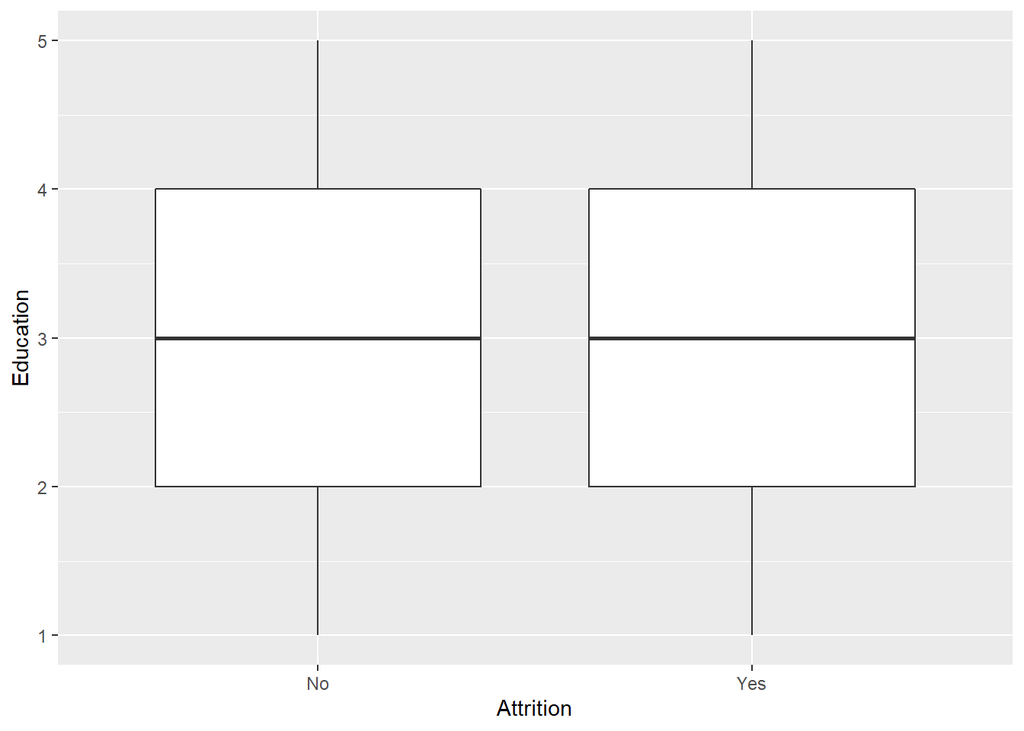

```r
# Education

Attr_Education <- ggplot(HR_Data, aes( x = HR_Data$Attrition  , y = HR_Data$Education))+
  geom_boxplot(stat ="boxplot" ,  outlier.colour = "red") + xlab("Attrition") + ylab("Education")

plot(Attr_Education)
```

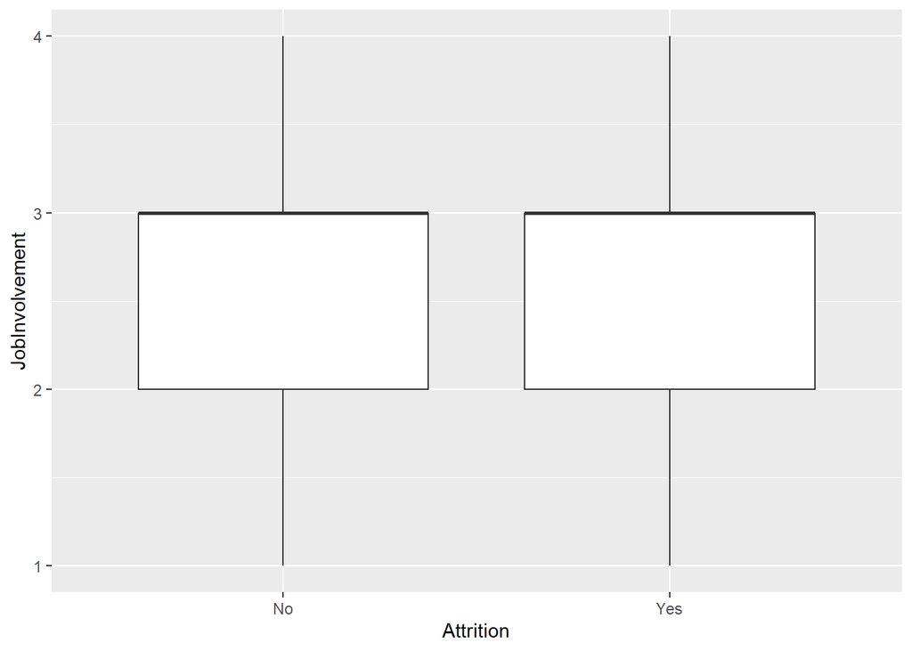

```r
# JobInvolvement

Attr_JobInvolvement <- ggplot(HR_Data, aes( x = HR_Data$Attrition  , y = HR_Data$JobInvolvement))+
  geom_boxplot(stat ="boxplot" ,  outlier.colour = "red") + xlab("Attrition") + ylab("JobInvolvement")

plot(Attr_JobInvolvement)
```

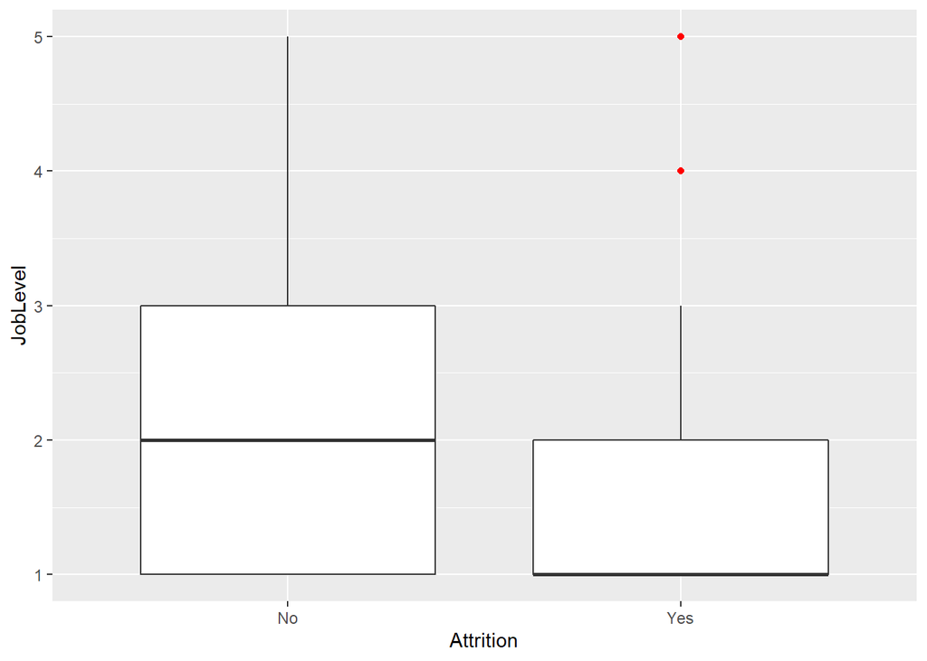

```r
# JobLevel


Attr_JobLevel <- ggplot(HR_Data, aes( x = HR_Data$Attrition  , y = HR_Data$JobLevel))+
  geom_boxplot(stat ="boxplot" ,  outlier.colour = "red") + xlab("Attrition") + ylab("JobLevel")

plot(Attr_JobLevel)
```

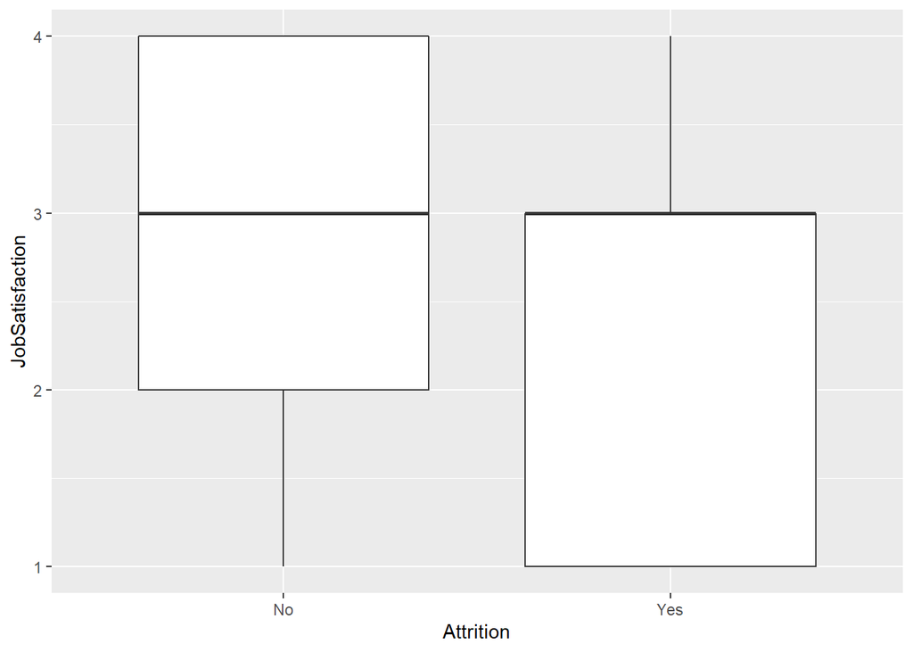

```r
# JobSatisfaction


Attr_JobSatisfaction <- ggplot(HR_Data, aes( x = HR_Data$Attrition  , y = HR_Data$JobSatisfaction))+
  geom_boxplot(stat ="boxplot" ,  outlier.colour = "red") + xlab("Attrition") + ylab("JobSatisfaction")


plot(Attr_JobSatisfaction)
```

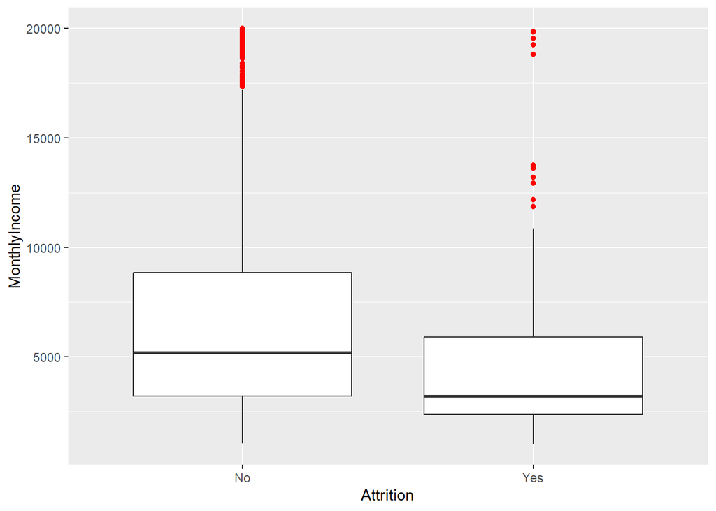

```r
# MonthlyIncome

Attr_MonthlyIncome <- ggplot(HR_Data, aes( x = HR_Data$Attrition  , y = HR_Data$MonthlyIncome))+
  geom_boxplot(stat ="boxplot" ,  outlier.colour = "red") + xlab("Attrition") + ylab("MonthlyIncome")


plot(Attr_MonthlyIncome)
```

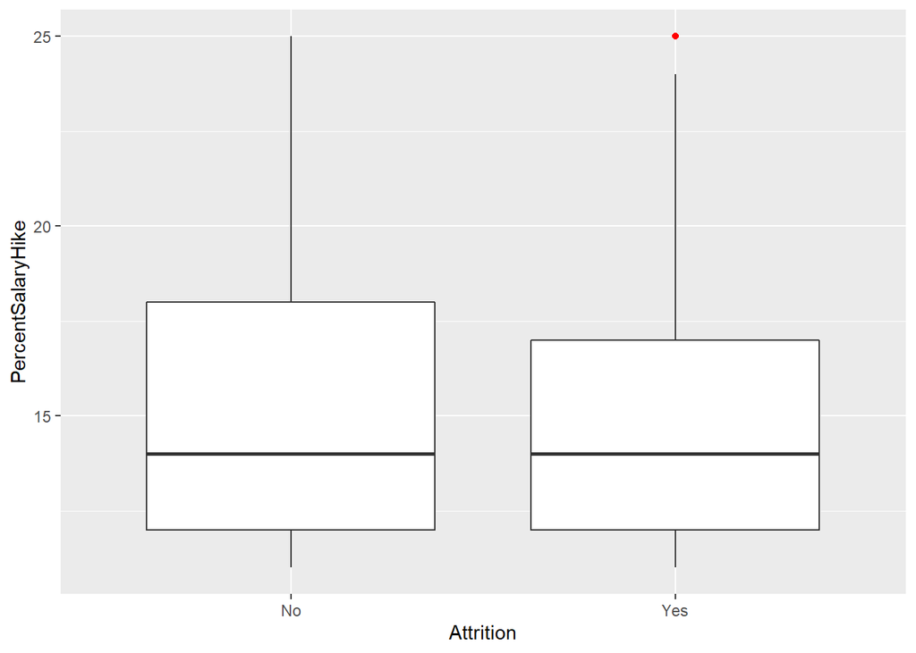

```r
# PercentSalaryHike

Attr_PercentSalaryHike <- ggplot(HR_Data, aes( x = HR_Data$Attrition  , y = HR_Data$PercentSalaryHike))+
  geom_boxplot(stat ="boxplot" ,  outlier.colour = "red") + xlab("Attrition") + ylab("PercentSalaryHike")


plot(Attr_PercentSalaryHike)
```

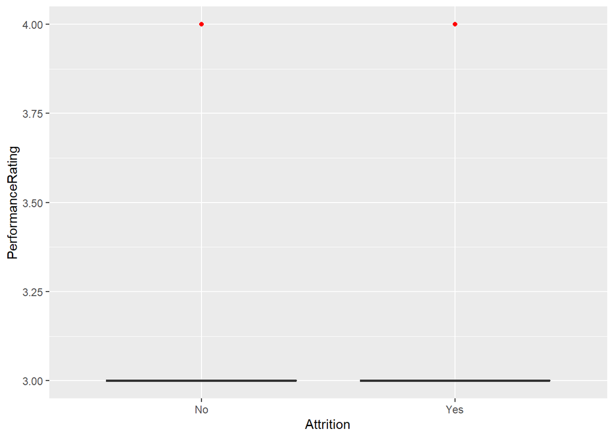

```r
#
# PerformanceRating
#
Attr_PerformanceRating <- ggplot(HR_Data, aes( x = HR_Data$Attrition  , y = HR_Data$PerformanceRating))+
  geom_boxplot(stat ="boxplot" ,  outlier.colour = "red") + xlab("Attrition") + ylab("PerformanceRating")


plot(Attr_PerformanceRating)
```

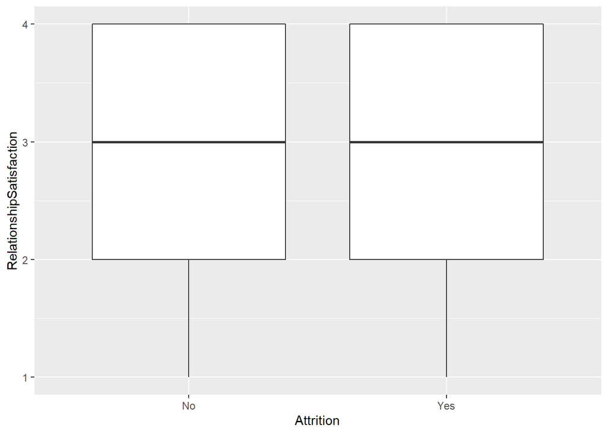

```r
# RelationshipSatisfaction
#

Attr_RelationshipSatisfaction <- ggplot(HR_Data, aes( x = HR_Data$Attrition  , y = HR_Data$RelationshipSatisfaction))+
  geom_boxplot(stat ="boxplot" ,  outlier.colour = "red") + xlab("Attrition") + ylab("RelationshipSatisfaction")


plot(Attr_RelationshipSatisfaction)
```

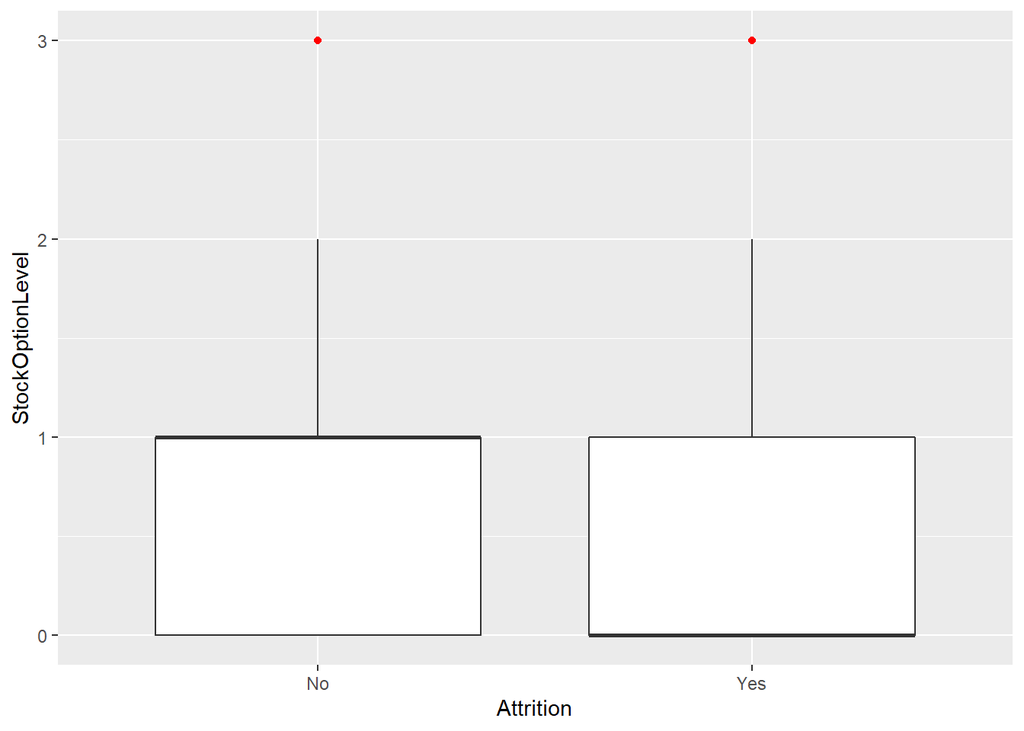

```r
# StockOptionLevel


Attr_StockOptionLevel <- ggplot(HR_Data, aes( x = HR_Data$Attrition  , y = HR_Data$StockOptionLevel))+
  geom_boxplot(stat ="boxplot" ,  outlier.colour = "red") + xlab("Attrition") + ylab("StockOptionLevel")


plot(Attr_StockOptionLevel)
```

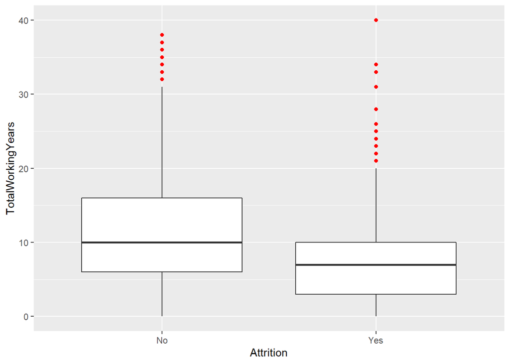

```r
#
# TotalWorkingYears
#
Attr_TotalWorkingYears <- ggplot(HR_Data, aes( x = HR_Data$Attrition  , y = HR_Data$TotalWorkingYears))+
  geom_boxplot(stat ="boxplot" ,  outlier.colour = "red") + xlab("Attrition") + ylab("TotalWorkingYears")


plot(Attr_TotalWorkingYears)
```

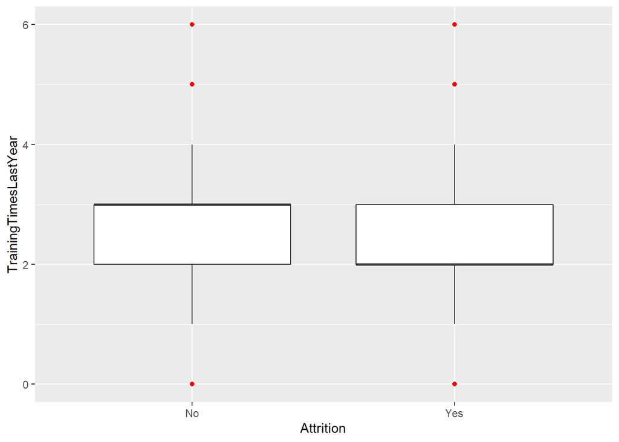

```r
# TrainingTimesLastYear

Attr_TrainingTimesLastYear <- ggplot(HR_Data, aes( x = HR_Data$Attrition  , y = HR_Data$TrainingTimesLastYear))+
  geom_boxplot(stat ="boxplot" ,  outlier.colour = "red") + xlab("Attrition") + ylab("TrainingTimesLastYear")


plot(Attr_TrainingTimesLastYear)
```

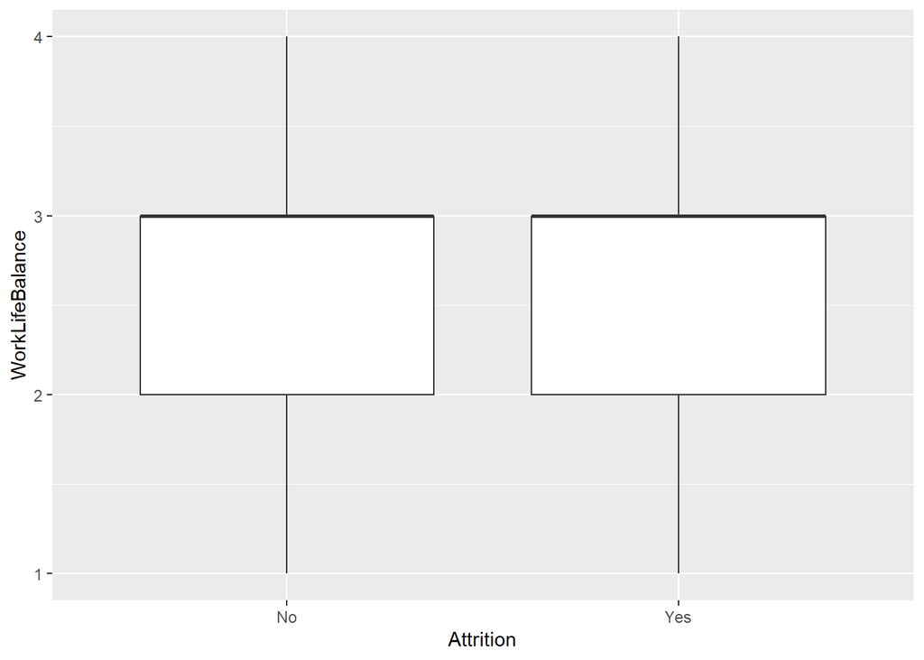

```r
#
# WorkLifeBalance
#

Attr_WorkLifeBalance <- ggplot(HR_Data, aes( x = HR_Data$Attrition  , y = HR_Data$WorkLifeBalance))+
  geom_boxplot(stat ="boxplot" ,  outlier.colour = "red") + xlab("Attrition") + ylab("WorkLifeBalance")


plot(Attr_WorkLifeBalance)
```

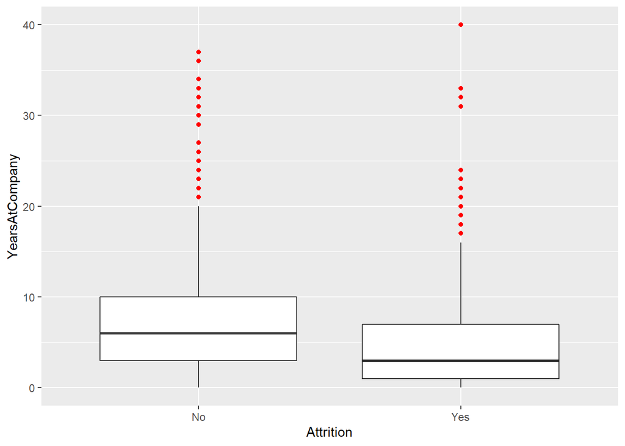

```r
#
# YearsAtCompany
#
Attr_YearsAtCompany <- ggplot(HR_Data, aes( x = HR_Data$Attrition  , y = HR_Data$YearsAtCompany))+
  geom_boxplot(stat ="boxplot" ,  outlier.colour = "red") + xlab("Attrition") + ylab("YearsAtCompany")


plot(Attr_YearsAtCompany)
```

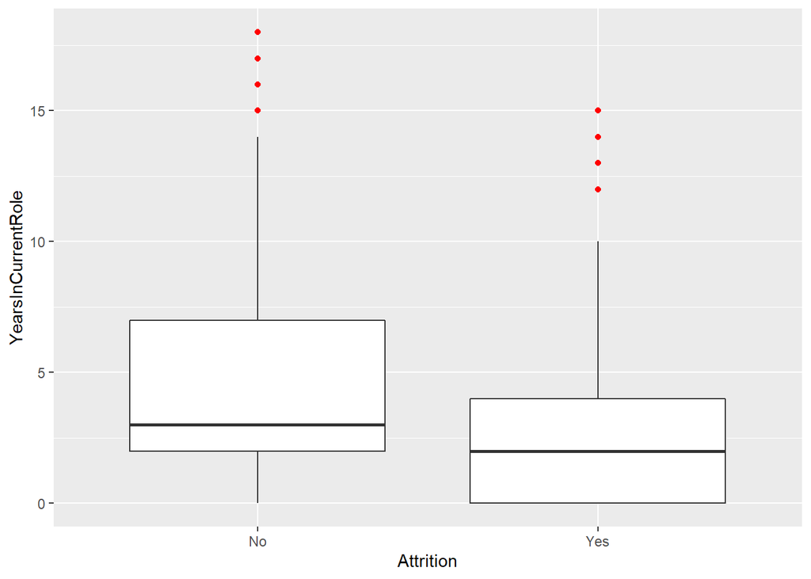

```r
# YearsInCurrentRole
#
Attr_YearsInCurrentRole <- ggplot(HR_Data, aes( x = HR_Data$Attrition  , y = HR_Data$YearsInCurrentRole))+
  geom_boxplot(stat ="boxplot" ,  outlier.colour = "red") + xlab("Attrition") + ylab("YearsInCurrentRole")


plot(Attr_YearsInCurrentRole)
```

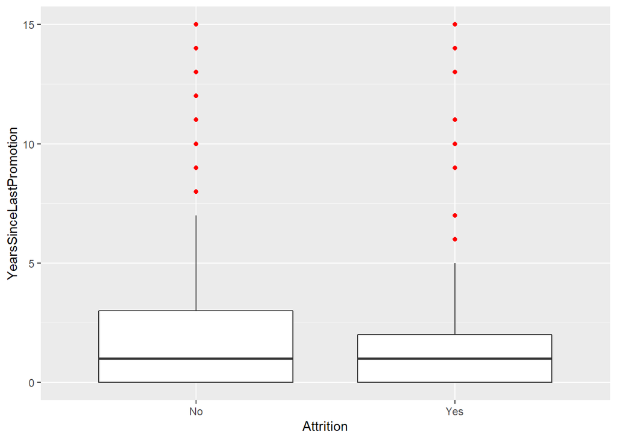

```r
# YearsSinceLastPromotion
#
Attr_YearsSinceLastPromotion <- ggplot(HR_Data, aes( x = HR_Data$Attrition  , y = HR_Data$YearsSinceLastPromotion))+
  geom_boxplot(stat ="boxplot" ,  outlier.colour = "red") + xlab("Attrition") + ylab("YearsSinceLastPromotion")


plot(Attr_YearsSinceLastPromotion)
```

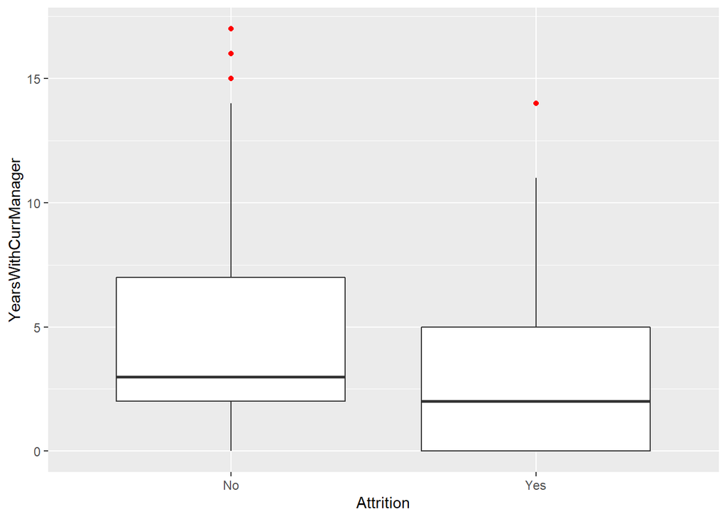

```r
#
# YearsWithCurrManager

Attr_YearsWithCurrManager <- ggplot(HR_Data, aes( x = HR_Data$Attrition  , y = HR_Data$YearsWithCurrManager))+
  geom_boxplot(stat ="boxplot" ,  outlier.colour = "red") + xlab("Attrition") + ylab("YearsWithCurrManager")


plot(Attr_YearsWithCurrManager)
```

```r
# ggarrange(Attr_Age , Attr_DistanceFromHome , Attr_Education,  Attr_JobInvolvement , Attr_JobLevel , Attr_JobSatisfaction , Attr_MonthlyIncome , Attr_PercentSalaryHike , Attr_PerformanceRating , Attr_RelationshipSatisfaction , Attr_StockOptionLevel , Attr_TotalWorkingYears , Attr_TrainingTimesLastYear , Attr_WorLifeBalance , Attr_YearsAtCompany , Attr_YearsInCurrentRole , Attr_YearsSinceLastPromotion , Attr_YearsWithCurrManager   + rremove("x.text"),heights = rep( 100 , each = 9), widths = c(15 ,15), ncol = 2, nrow = 9)
```

*Begin Decision tree analysis*

```r
str(HR_Data)
```

```
## Classes 'spec_tbl_df', 'tbl_df', 'tbl' and 'data.frame': 2940 obs. of  35 variables:
##  $ Age                     : num  41 49 37 33 27 32 59 30 38 36 ...
##  $ Attrition               : Factor w/ 2 levels "No","Yes": 2 1 2 1 1 1 1 1 1 1 ...
##  $ BusinessTravel          : Factor w/ 3 levels "Non-Travel","Travel_Frequently",..: 3 2 3 2 3 2 3 3 2 3 ...
##  $ DailyRate               : num  1102 279 1373 1392 591 ...
##  $ Department              : Factor w/ 3 levels "Human Resources",..: 3 2 2 2 2 2 2 2 2 2 ...
##  $ DistanceFromHome        : num  1 8 2 3 2 2 3 24 23 27 ...
##  $ Education               : num  2 1 2 4 1 2 3 1 3 3 ...
##  $ EducationField          : Factor w/ 6 levels "Human Resources",..: 2 2 5 2 4 2 4 2 2 4 ...
##  $ EmployeeCount           : num  1 1 1 1 1 1 1 1 1 1 ...
##  $ EmployeeNumber          : num  1 2 3 4 5 6 7 8 9 10 ...
##  $ EnvironmentSatisfaction : num  2 3 4 4 1 4 3 4 4 3 ...
##  $ Gender                  : Factor w/ 2 levels "Female","Male": 1 2 2 1 2 2 1 2 2 2 ...
##  $ HourlyRate              : num  94 61 92 56 40 79 81 67 44 94 ...
##  $ JobInvolvement          : num  3 2 2 3 3 3 4 3 2 3 ...
##  $ JobLevel                : num  2 2 1 1 1 1 1 1 3 2 ...
##  $ JobRole                 : Factor w/ 9 levels "Healthcare Representative",..: 8 7 3 7 3 3 3 3 5 1 ...
##  $ JobSatisfaction         : num  4 2 3 3 2 4 1 3 3 3 ...
##  $ MaritalStatus           : Factor w/ 3 levels "Divorced","Married",..: 3 2 3 2 2 3 2 1 3 2 ...
##  $ MonthlyIncome           : num  5993 5130 2090 2909 3468 ...
##  $ MonthlyRate             : num  19479 24907 2396 23159 16632 ...
##  $ NumCompaniesWorked      : num  8 1 6 1 9 0 4 1 0 6 ...
##  $ Over18                  : Factor w/ 1 level "Y": 1 1 1 1 1 1 1 1 1 1 ...
##  $ OverTime                : Factor w/ 2 levels "No","Yes": 2 1 2 2 1 1 2 1 1 1 ...
##  $ PercentSalaryHike       : num  11 23 15 11 12 13 20 22 21 13 ...
##  $ PerformanceRating       : num  3 4 3 3 3 3 4 4 4 3 ...
##  $ RelationshipSatisfaction: num  1 4 2 3 4 3 1 2 2 2 ...
##  $ StandardHours           : num  80 80 80 80 80 80 80 80 80 80 ...
##  $ StockOptionLevel        : num  0 1 0 0 1 0 3 1 0 2 ...
##  $ TotalWorkingYears       : num  8 10 7 8 6 8 12 1 10 17 ...
##  $ TrainingTimesLastYear   : num  0 3 3 3 3 2 3 2 2 3 ...
##  $ WorkLifeBalance         : num  1 3 3 3 3 2 2 3 3 2 ...
##  $ YearsAtCompany          : num  6 10 0 8 2 7 1 1 9 7 ...
##  $ YearsInCurrentRole      : num  4 7 0 7 2 7 0 0 7 7 ...
##  $ YearsSinceLastPromotion : num  0 1 0 3 2 3 0 0 1 7 ...
##  $ YearsWithCurrManager    : num  5 7 0 0 2 6 0 0 8 7 ...
##  - attr(*, "spec")=
##   .. cols(
##   ..   Age = col_double(),
##   ..   Attrition = col_character(),
```

[output cut: 19 more lines]

```
##   ..   Over18 = col_character(),
##   ..   OverTime = col_character(),
##   ..   PercentSalaryHike = col_double(),
##   ..   PerformanceRating = col_double(),
##   ..   RelationshipSatisfaction = col_double(),
##   ..   StandardHours = col_double(),
##   ..   StockOptionLevel = col_double(),
##   ..   TotalWorkingYears = col_double(),
##   ..   TrainingTimesLastYear = col_double(),
##   ..   WorkLifeBalance = col_double(),
##   ..   YearsAtCompany = col_double(),
##   ..   YearsInCurrentRole = col_double(),
##   ..   YearsSinceLastPromotion = col_double(),
##   ..   YearsWithCurrManager = col_double()
##   .. )
```

```r
prop.table(table(HR_Data$Attrition))
```

```
##
##        No       Yes
## 0.8387755 0.1612245
```

```r
library(caTools)
library(caret)
library(rpart)
```

```r
library(rpart.plot)
```

*Based on the dataset shared , the data doesn’t seem be extremely biased towards a specific class i.e class of Yes / No*

```r
## split into training and test sets


set.seed(123)
split = sample.split(HR_Data$Attrition, SplitRatio = 0.7)
HR_traindata = subset(HR_Data, split == TRUE)
HR_testdata = subset(HR_Data, split == FALSE)

## Check if distribution of partition data is correct Testing dataset


# Check the distribution of the proportion in train and test data as well

prop.table(table(HR_traindata$Attrition))
```

```
##
##        No       Yes
## 0.8386783 0.1613217
```

```r
prop.table(table(HR_testdata$Attrition))
```

```
##
##        No       Yes
## 0.8390023 0.1609977
```

*Post split , its seen that train and test data are split retaining the same ratio between Yes and No* *We should drop the 4 columns , which are not significant , as there is no criteria for them to split*

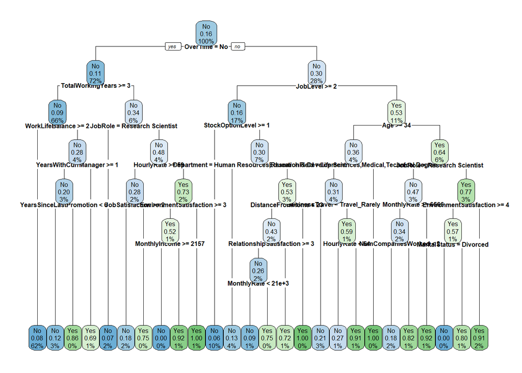

```r
# Develop a fully grown tree
set.seed(123)

# data$EmployeeCount = NULL
# data$EmployeeNumber = NULL
# data$Over18 = NULL
# data$StandardHours = NULL

hr_tree_full = rpart(formula = HR_traindata$Attrition~., data = HR_traindata , method = "class" )
rpart.plot(hr_tree_full, cex=0.5)
```

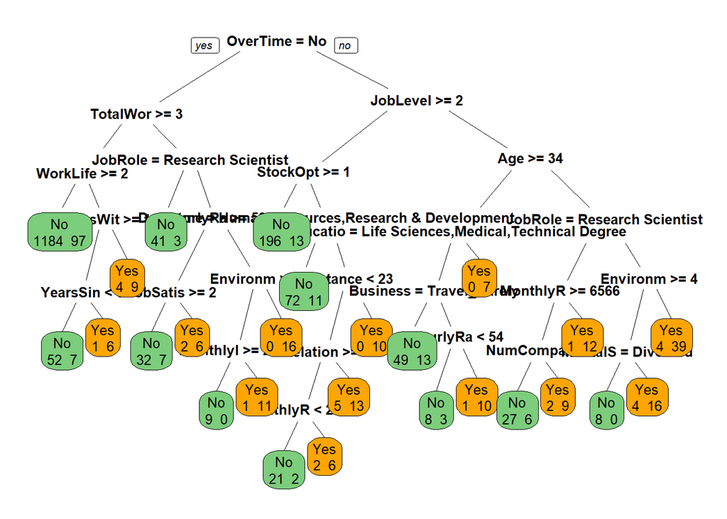

```r
boxcols <- c("palegreen3", "orange")[hr_tree_full$frame$yval]

par(xpd=TRUE)
prp(hr_tree_full, faclen = 0, cex = 0.8, extra = 1, box.col = boxcols)
```

```r
#summary(tree_full)
```

```r
#summary(hr_tree_fulltree_full)
hr_tree_full$variable.importance
```

```
##                  JobRole            MonthlyIncome        TotalWorkingYears
##                53.581458                50.985706                46.846094
##                 JobLevel                      Age                 OverTime
##                36.609214                32.337837                29.560112
##           YearsAtCompany              MonthlyRate               HourlyRate
##                25.726497                17.200791                16.159010
##         StockOptionLevel       NumCompaniesWorked           EducationField
##                15.926418                15.618099                14.531594
##            MaritalStatus               Department  EnvironmentSatisfaction
##                13.766011                13.234490                13.132521
##     YearsWithCurrManager       YearsInCurrentRole                DailyRate
##                12.560925                12.490785                12.490702
##  YearsSinceLastPromotion          JobSatisfaction         DistanceFromHome
##                 9.802058                 9.737403                 9.446297
##          WorkLifeBalance        PercentSalaryHike           BusinessTravel
##                 6.936529                 6.720520                 6.548583
## RelationshipSatisfaction           JobInvolvement           EmployeeNumber
##                 6.217770                 6.067617                 3.095307
##                Education                   Gender    TrainingTimesLastYear
##                 2.525662                 1.619835                 1.304698
##        PerformanceRating
##                 1.287001
```

```r
hr_df_cart=data.frame(round(hr_tree_full$variable.importance,2))
hr_df_cart
```

```
##                          round.hr_tree_full.variable.importance..2.
## JobRole                                                       53.58
## MonthlyIncome                                                 50.99
## TotalWorkingYears                                             46.85
## JobLevel                                                      36.61
## Age                                                           32.34
## OverTime                                                      29.56
## YearsAtCompany                                                25.73
## MonthlyRate                                                   17.20
## HourlyRate                                                    16.16
## StockOptionLevel                                              15.93
## NumCompaniesWorked                                            15.62
## EducationField                                                14.53
## MaritalStatus                                                 13.77
## Department                                                    13.23
## EnvironmentSatisfaction                                       13.13
## YearsWithCurrManager                                          12.56
## YearsInCurrentRole                                            12.49
## DailyRate                                                     12.49
## YearsSinceLastPromotion                                        9.80
## JobSatisfaction                                                9.74
## DistanceFromHome                                               9.45
## WorkLifeBalance                                                6.94
## PercentSalaryHike                                              6.72
## BusinessTravel                                                 6.55
## RelationshipSatisfaction                                       6.22
## JobInvolvement                                                 6.07
## EmployeeNumber                                                 3.10
## Education                                                      2.53
## Gender                                                         1.62
## TrainingTimesLastYear                                          1.30
## PerformanceRating                                              1.29
```

*Predict using Train and Test Dataset*

```r
## Predict using the CART model
HR_traindata$predict.class=predict(hr_tree_full,HR_traindata,type="class")
HR_traindata$predict.score=predict(hr_tree_full,HR_traindata)
head(HR_traindata$predict.score)
```

```
##          No        Yes
## 1 0.2777778 0.72222222
## 2 0.9242779 0.07572209
## 3 0.8181818 0.18181818
## 4 0.9242779 0.07572209
## 5 0.9242779 0.07572209
## 6 0.7903226 0.20967742
```

```r
## Creating the confusion matrix
tabtrain=with(HR_traindata,table(HR_traindata$Attrition,predict.class))
tabtrain
```

```
##      predict.class
##         No  Yes
##   No  1699   27
##   Yes  162  170
```

```r
TN_train = tabtrain[1,1]
TP_train = tabtrain[2,2]
FN_train = tabtrain[2,1]
FP_train = tabtrain[1,2]

train_acc = (TN_train+TP_train)/(TN_train+TP_train+FN_train+FP_train)
train_acc
```

```
## [1] 0.9081633
```

```r
train_sens = TP_train/(TP_train+FN_train)
train_sens
```

```
## [1] 0.5120482
```

```r
train_spec = TN_train/(TN_train+FP_train)
train_spec
```

```
## [1] 0.9843569
```

```r
# Prediction on Test Data using the same tree built

## Predict using the CART model
HR_testdata$predict.class=predict(hr_tree_full,HR_testdata,type="class")
HR_testdata$predict.score=predict(hr_tree_full,HR_testdata)

## Creating the confusion matrix
tabtest=with(HR_testdata,table(HR_testdata$Attrition,predict.class))
tabtest
```

```
##      predict.class
##        No Yes
##   No  719  21
##   Yes  82  60
```

```r
TN_test = tabtest[1,1]
TP_test = tabtest[2,2]
FN_test = tabtest[2,1]
FP_test = tabtest[1,2]

test_acc = (TN_test+TP_test)/(TN_test+TP_test+FN_test+FP_test)
test_acc
```

```
## [1] 0.88322
```

```r
test_sens = TP_test/(TP_test+FN_test)
test_sens
```

```
## [1] 0.4225352
```

```r
test_spec = TN_test/(TN_test+FP_test)
test_spec
```

```
## [1] 0.9716216
```

*Comparing the results of train and test*

```r
hr_df_results_train = data.frame(train_acc, train_sens, train_spec)
names(hr_df_results_train) = c("ACC", "SENS", "SPEC")
hr_df_results_test = data.frame(test_acc, test_sens, test_spec)
names(hr_df_results_test) = c("ACC", "SENS", "SPEC")

?rbind
```

```
## starting httpd help server ... done
```

```r
hr_df_final =rbind(hr_df_results_train, hr_df_results_test)
row.names(hr_df_final) = c('hr_tree_full_train', 'hr_tree_full_test')
hr_df_final
```

```
##                          ACC      SENS      SPEC
## hr_tree_full_train 0.9081633 0.5120482 0.9843569
## hr_tree_full_test  0.8832200 0.4225352 0.9716216
```

*Model is performing relatively closer wrt Train and test data* *Next steps are to optimize the model , to validate for better accuracy and performance*

*Optimization chosen is by means of pruning the tree based on CV Error, which is minimum*

```r
# Some cleanup before building the next tree

#remove predicted score and class before running other models
HR_traindata$predict.class = NULL
HR_traindata$predict.score = NULL
HR_testdata$predict.class = NULL
HR_testdata$predict.score = NULL
```

```r
hr_ptree = prune(hr_tree_full, cp= 0.00001 ,"CP" )
printcp(hr_ptree)
```

```
##
## Classification tree:
## rpart(formula = HR_traindata$Attrition ~ ., data = HR_traindata,
##     method = "class")
##
## Variables actually used in tree construction:
##  [1] Age                      BusinessTravel
##  [3] Department               DistanceFromHome
##  [5] EducationField           EnvironmentSatisfaction
##  [7] HourlyRate               JobLevel
##  [9] JobRole                  JobSatisfaction
## [11] MaritalStatus            MonthlyIncome
## [13] MonthlyRate              NumCompaniesWorked
## [15] OverTime                 RelationshipSatisfaction
## [17] StockOptionLevel         TotalWorkingYears
## [19] WorkLifeBalance          YearsSinceLastPromotion
## [21] YearsWithCurrManager
##
## Root node error: 332/2058 = 0.16132
##
## n= 2058
##
##         CP nsplit rel error  xerror     xstd
## 1 0.036145      0   1.00000 1.00000 0.050261
## 2 0.021084      3   0.89157 0.99699 0.050200
## 3 0.017068      7   0.80723 0.96687 0.049578
## 4 0.013554     10   0.75602 0.90060 0.048151
## 5 0.012048     18   0.64759 0.88253 0.047747
## 6 0.010040     22   0.59940 0.85843 0.047197
## 7 0.010000     25   0.56928 0.84337 0.046847
```

```r
hr_ptree
```

```
## n= 2058
##
## node), split, n, loss, yval, (yprob)
##       * denotes terminal node
##
##   1) root 2058 332 No (0.83867833 0.16132167)
##     2) OverTime=No 1488 162 No (0.89112903 0.10887097)
##       4) TotalWorkingYears>=2.5 1360 119 No (0.91250000 0.08750000)
##         8) WorkLifeBalance>=1.5 1281  97 No (0.92427791 0.07572209) *
##         9) WorkLifeBalance< 1.5 79  22 No (0.72151899 0.27848101)
##          18) YearsWithCurrManager>=0.5 66  13 No (0.80303030 0.19696970)
##            36) YearsSinceLastPromotion< 6 59   7 No (0.88135593 0.11864407) *
##            37) YearsSinceLastPromotion>=6 7   1 Yes (0.14285714 0.85714286) *
##          19) YearsWithCurrManager< 0.5 13   4 Yes (0.30769231 0.69230769) *
##       5) TotalWorkingYears< 2.5 128  43 No (0.66406250 0.33593750)
##        10) JobRole=Research Scientist 44   3 No (0.93181818 0.06818182) *
##        11) JobRole=Human Resources,Laboratory Technician,Sales Representative 84  40 No (0.52380952 0.47619048)
##          22) HourlyRate>=58.5 47  13 No (0.72340426 0.27659574)
##            44) JobSatisfaction>=1.5 39   7 No (0.82051282 0.17948718) *
##            45) JobSatisfaction< 1.5 8   2 Yes (0.25000000 0.75000000) *
##          23) HourlyRate< 58.5 37  10 Yes (0.27027027 0.72972973)
##            46) EnvironmentSatisfaction>=2.5 21  10 Yes (0.47619048 0.52380952)
##              92) MonthlyIncome>=2156.5 9   0 No (1.00000000 0.00000000) *
##              93) MonthlyIncome< 2156.5 12   1 Yes (0.08333333 0.91666667) *
##            47) EnvironmentSatisfaction< 2.5 16   0 Yes (0.00000000 1.00000000) *
##     3) OverTime=Yes 570 170 No (0.70175439 0.29824561)
##       6) JobLevel>=1.5 351  55 No (0.84330484 0.15669516)
##        12) StockOptionLevel>=0.5 209  13 No (0.93779904 0.06220096) *
##        13) StockOptionLevel< 0.5 142  42 No (0.70422535 0.29577465)
##          26) Department=Human Resources,Research & Development 83  11 No (0.86746988 0.13253012) *
##          27) Department=Sales 59  28 Yes (0.47457627 0.52542373)
##            54) DistanceFromHome< 22.5 49  21 No (0.57142857 0.42857143)
##             108) RelationshipSatisfaction>=2.5 31   8 No (0.74193548 0.25806452)
##               216) MonthlyRate< 21282 23   2 No (0.91304348 0.08695652) *
##               217) MonthlyRate>=21282 8   2 Yes (0.25000000 0.75000000) *
##             109) RelationshipSatisfaction< 2.5 18   5 Yes (0.27777778 0.72222222) *
##            55) DistanceFromHome>=22.5 10   0 Yes (0.00000000 1.00000000) *
##       7) JobLevel< 1.5 219 104 Yes (0.47488584 0.52511416)
##        14) Age>=33.5 91  33 No (0.63736264 0.36263736)
##          28) EducationField=Life Sciences,Medical,Technical Degree 84  26 No (0.69047619 0.30952381)
##            56) BusinessTravel=Travel_Rarely 62  13 No (0.79032258 0.20967742) *
##            57) BusinessTravel=Non-Travel,Travel_Frequently 22   9 Yes (0.40909091 0.59090909)
##             114) HourlyRate< 53.5 11   3 No (0.72727273 0.27272727) *
##             115) HourlyRate>=53.5 11   1 Yes (0.09090909 0.90909091) *
##          29) EducationField=Human Resources,Marketing,Other 7   0 Yes (0.00000000 1.00000000) *
##        15) Age< 33.5 128  46 Yes (0.35937500 0.64062500)
##          30) JobRole=Research Scientist 57  27 No (0.52631579 0.47368421)
##            60) MonthlyRate>=6566 44  15 No (0.65909091 0.34090909)
##             120) NumCompaniesWorked< 2 33   6 No (0.81818182 0.18181818) *
##             121) NumCompaniesWorked>=2 11   2 Yes (0.18181818 0.81818182) *
##            61) MonthlyRate< 6566 13   1 Yes (0.07692308 0.92307692) *
##          31) JobRole=Human Resources,Laboratory Technician,Sales Representative 71  16 Yes (0.22535211 0.77464789)
##            62) EnvironmentSatisfaction>=3.5 28  12 Yes (0.42857143 0.57142857)
##             124) MaritalStatus=Divorced 8   0 No (1.00000000 0.00000000) *
##             125) MaritalStatus=Married,Single 20   4 Yes (0.20000000 0.80000000) *
##            63) EnvironmentSatisfaction< 3.5 43   4 Yes (0.09302326 0.90697674) *
```

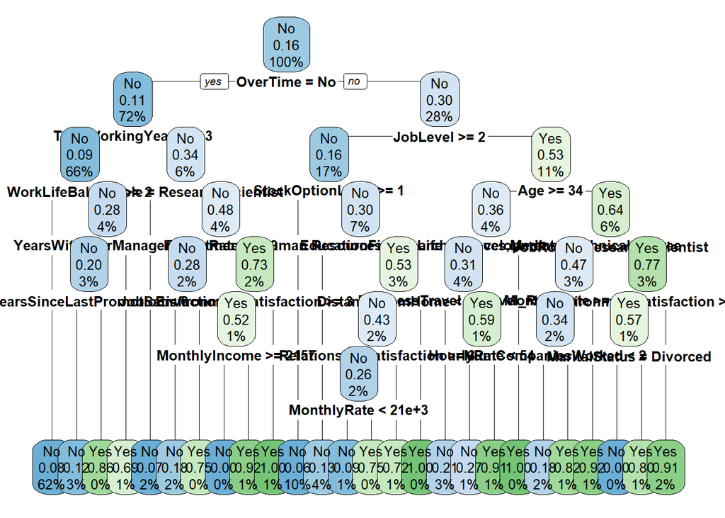

```r
# rpart.plot(hr_ptree)

rpart.plot(hr_ptree, cex=0.8)
```

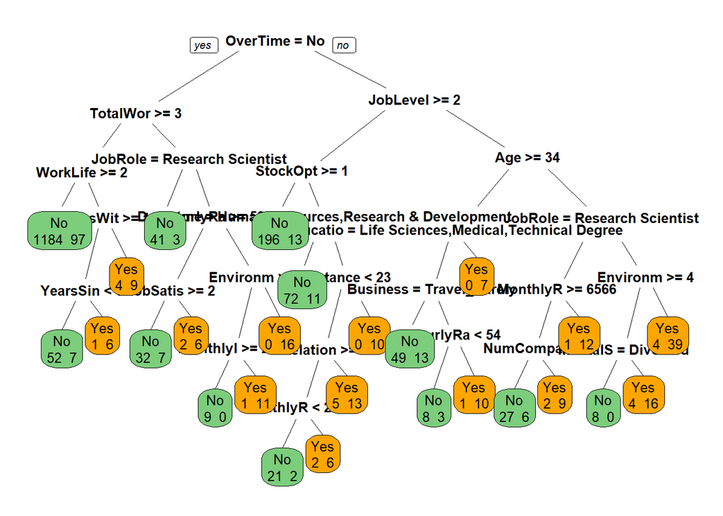

```r
boxcols <- c("palegreen3", "orange")[hr_ptree$frame$yval]

par(xpd=TRUE)
prp(hr_ptree, faclen = 0, cex = 0.8, extra = 1, box.col = boxcols)
```

```r
#Variable Importance
hr_ptree$variable.importance
```

```
##                  JobRole            MonthlyIncome        TotalWorkingYears
##                53.581458                50.985706                46.846094
##                 JobLevel                      Age                 OverTime
##                36.609214                32.337837                29.560112
##           YearsAtCompany              MonthlyRate               HourlyRate
##                25.726497                17.200791                16.159010
##         StockOptionLevel       NumCompaniesWorked           EducationField
##                15.926418                15.618099                14.531594
##            MaritalStatus               Department  EnvironmentSatisfaction
##                13.766011                13.234490                13.132521
##     YearsWithCurrManager       YearsInCurrentRole                DailyRate
##                12.560925                12.490785                12.490702
##  YearsSinceLastPromotion          JobSatisfaction         DistanceFromHome
##                 9.802058                 9.737403                 9.446297
##          WorkLifeBalance        PercentSalaryHike           BusinessTravel
##                 6.936529                 6.720520                 6.548583
## RelationshipSatisfaction           JobInvolvement           EmployeeNumber
##                 6.217770                 6.067617                 3.095307
##                Education                   Gender    TrainingTimesLastYear
##                 2.525662                 1.619835                 1.304698
##        PerformanceRating
##                 1.287001
```

```r
#summary(hr_tree_fulltree_full)
hr_ptree$variable.importance
```

```
##                  JobRole            MonthlyIncome        TotalWorkingYears
##                53.581458                50.985706                46.846094
##                 JobLevel                      Age                 OverTime
##                36.609214                32.337837                29.560112
##           YearsAtCompany              MonthlyRate               HourlyRate
##                25.726497                17.200791                16.159010
##         StockOptionLevel       NumCompaniesWorked           EducationField
##                15.926418                15.618099                14.531594
##            MaritalStatus               Department  EnvironmentSatisfaction
##                13.766011                13.234490                13.132521
##     YearsWithCurrManager       YearsInCurrentRole                DailyRate
##                12.560925                12.490785                12.490702
##  YearsSinceLastPromotion          JobSatisfaction         DistanceFromHome
##                 9.802058                 9.737403                 9.446297
##          WorkLifeBalance        PercentSalaryHike           BusinessTravel
##                 6.936529                 6.720520                 6.548583
## RelationshipSatisfaction           JobInvolvement           EmployeeNumber
##                 6.217770                 6.067617                 3.095307
##                Education                   Gender    TrainingTimesLastYear
##                 2.525662                 1.619835                 1.304698
##        PerformanceRating
##                 1.287001
```

```r
hr_df_cart=data.frame(round(hr_ptree$variable.importance,2))
hr_df_cart
```

```
##                          round.hr_ptree.variable.importance..2.
## JobRole                                                   53.58
## MonthlyIncome                                             50.99
## TotalWorkingYears                                         46.85
## JobLevel                                                  36.61
## Age                                                       32.34
## OverTime                                                  29.56
## YearsAtCompany                                            25.73
## MonthlyRate                                               17.20
## HourlyRate                                                16.16
## StockOptionLevel                                          15.93
## NumCompaniesWorked                                        15.62
## EducationField                                            14.53
## MaritalStatus                                             13.77
## Department                                                13.23
## EnvironmentSatisfaction                                   13.13
## YearsWithCurrManager                                      12.56
## YearsInCurrentRole                                        12.49
## DailyRate                                                 12.49
## YearsSinceLastPromotion                                    9.80
## JobSatisfaction                                            9.74
## DistanceFromHome                                           9.45
## WorkLifeBalance                                            6.94
## PercentSalaryHike                                          6.72
## BusinessTravel                                             6.55
## RelationshipSatisfaction                                   6.22
## JobInvolvement                                             6.07
## EmployeeNumber                                             3.10
## Education                                                  2.53
## Gender                                                     1.62
## TrainingTimesLastYear                                      1.30
## PerformanceRating                                          1.29
```

*Predict using Train and Test Dataset of pruned Tree , pruned on CP*

```r
## Predict using the CART model
HR_traindata$predict.class=predict(hr_ptree,HR_traindata,type="class")
HR_traindata$predict.score=predict(hr_ptree,HR_traindata)
head(HR_traindata$predict.score)
```

```
##          No        Yes
## 1 0.2777778 0.72222222
## 2 0.9242779 0.07572209
## 3 0.8181818 0.18181818
## 4 0.9242779 0.07572209
## 5 0.9242779 0.07572209
## 6 0.7903226 0.20967742
```

```r
## Creating the confusion matrix
tabtrain=with(HR_traindata,table(HR_traindata$Attrition,predict.class))
tabtrain
```

```
##      predict.class
##         No  Yes
##   No  1699   27
##   Yes  162  170
```

```r
TN_train = tabtrain[1,1]
TP_train = tabtrain[2,2]
FN_train = tabtrain[2,1]
FP_train = tabtrain[1,2]

train_acc = (TN_train+TP_train)/(TN_train+TP_train+FN_train+FP_train)
train_acc
```

```
## [1] 0.9081633
```

```r
train_sens = TP_train/(TP_train+FN_train)
train_sens
```

```
## [1] 0.5120482
```

```r
train_spec = TN_train/(TN_train+FP_train)
train_spec
```

```
## [1] 0.9843569
```

```r
# Prediction on Test Data using the same tree built

## Predict using the CART model
HR_testdata$predict.class=predict(hr_ptree,HR_testdata,type="class")
HR_testdata$predict.score=predict(hr_ptree,HR_testdata)

## Creating the confusion matrix
tabtest=with(HR_testdata,table(HR_testdata$Attrition,predict.class))
tabtest
```

```
##      predict.class
##        No Yes
##   No  719  21
##   Yes  82  60
```

```r
TN_test = tabtest[1,1]
TP_test = tabtest[2,2]
FN_test = tabtest[2,1]
FP_test = tabtest[1,2]

test_acc = (TN_test+TP_test)/(TN_test+TP_test+FN_test+FP_test)
test_acc
```

```
## [1] 0.88322
```

```r
test_sens = TP_test/(TP_test+FN_test)
test_sens
```

```
## [1] 0.4225352
```

```r
test_spec = TN_test/(TN_test+FP_test)
test_spec
```

```
## [1] 0.9716216
```

*Comparing the results of train and test of a pruned tree pruned on cp*

```r
hr_df_results_train = data.frame(train_acc, train_sens, train_spec)
names(hr_df_results_train) = c("ACC", "SENS", "SPEC")
hr_df_results_test = data.frame(test_acc, test_sens, test_spec)
names(hr_df_results_test) = c("ACC", "SENS", "SPEC")

?rbind
hr_df_final =rbind(hr_df_results_train, hr_df_results_test)
row.names(hr_df_final) = c('hr_pruned_cp_tree_train', 'hr_pruned_cp_tree_test')
hr_df_final
```

```
##                               ACC      SENS      SPEC
## hr_pruned_cp_tree_train 0.9081633 0.5120482 0.9843569
## hr_pruned_cp_tree_test  0.8832200 0.4225352 0.9716216
```

*Not much of change seen after pruning the tree based on CP* *Try pruning the tree based on lowest value of CV , which is considering the option of pruning based on best CP*